# Contagem com Interrupção em JavaFX

LP4A/PUCSP, ItaloSV, 2018

# 1 Serviços Interrompíveis de Contagem

A arquitetura deste experimento final de contagem com interrupção encontra-se documentada no diagrama UML mostrado na fig. 1.

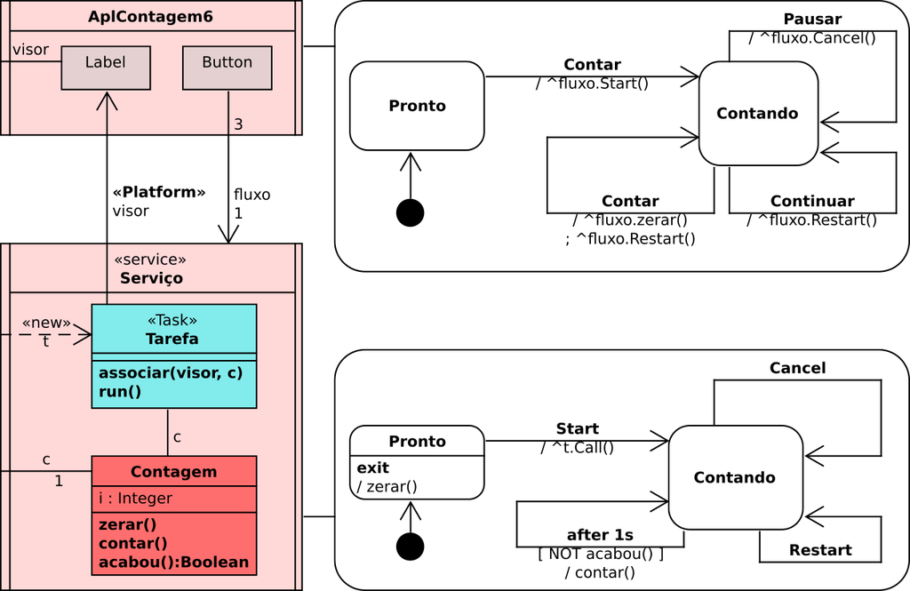

Figura 1: Comunicação assíncrona entre máquinas de estados

Observamos a presença de duas classes ativas, bem como as respectivas regiões do programa reservadas para elas. Cabe ressaltar que um **Serviço** jamais poderá fazer uso de instruções da área reservada para a **AplContagem6** diretamente: apenas por meio do conector **Plataform**.

**Eventos Contar** Para tratar ocorrências de eventos **Contar**, faremos a máquina executar instruções de acordo como modelo de computação mostrado no diagrama de sequências de mensagens (DSM)—fig. 2.

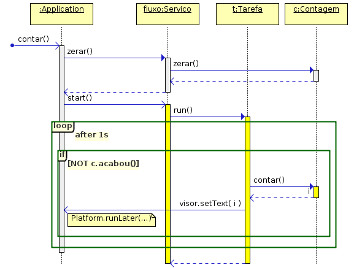

Figura 2: Reação a eventos **Contar**

Em amarelo, sinalizamos instruções executadas pelo fluxo de controle adicional do serviço.

**Eventos Pausar** Por outro lado, a ocorrência de eventos **Pausar** ocasiona o cancelamento da execução do fluxo adicional. Sendo uma classe descendente de `Service`, no entanto, poderemos enviar mensagens do tipo `restart()` a qualquer momento, visando o início (ou reinício) do processo de contagem (fig. 3).

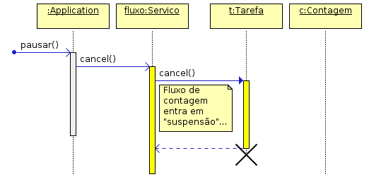

Figura 3: Reação a eventos **Pausar**

**Eventos Continuar** Caso a contagem ainda não tenha se encerrado, poderemos solicitar que continue, gerando um evento do tipo **Continuar**—fig. 4.

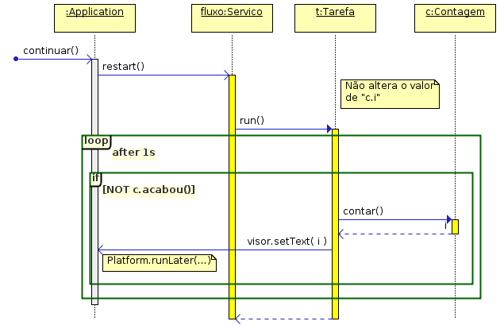

Figura 4: Reação a eventos **Continuar**

# 2 Contagem 6

## 2.1 Classe `Contagem`

A classe `Contagem` implementa o processo de contagem (ou de geração de números entre 1 e 10). A lst. 1 mostra o código desta classe.

Listagem 1: Interface exigida

```java
// Contagem (0.6)::
class Contagem {

    Contagem() {
        i = 1;
    }
    int i;

    void contar() {
        i++;
    }

    void zerar() {
        i = 1;
    }

    boolean acabou() {
        return i > 10;
    }

    @Override
    public String toString() {
        return "" + i;
    }
}
```

## 2.2 Classe `Tarefa`

A tarefa a ser executada neste experimento (e nos demais desta série) é de geração da sequência $\langle 1,2,\cdots,10 \rangle$. As instruções que descrevem a lógica de geração serão executadas pelo fluxo JavaFX, o que deve ser evitado em situações de tarefas “demoradas”. Para simular uma tarefa deste tipo, acrescentaremos uma instrução que suspende a execução do objeto ativo contendo o fluxo de controle JavaFX (lst. 2).

Listagem 2: Interface exigida

```java
// mwe.contagem6.Tarefa (0.6)::
import javafx.application.Platform;
import javafx.concurrent.Task;
import javafx.scene.control.Label;
// class Tarefa extends Task<Void> {...} <--
```

**Associação da tarefa** Após gerar um novo elemento da sequência de números, deveremos comandar a atualização do visor da tela. O suporte a esta parte da computação envolverá a ligação entre um objeto tarefa e um objeto visor da classe `Label` (lst. 3).

Listagem 3: Associação da tarefa com o visor da tela

```java
    // mwe.contagem6.Tarefa (0.6)::
    void associar(Label v) {
        visor = v;
    }
    Label visor;

    void associar(Contagem c) {
        contador = c;
    }
    Contagem contador;
```

**Lógica da contagem** Por último, implementamos a lógica do processo de contagem no método `call()` (lst. 4).

Listagem 4: Lógica de controle do fluxo adicional de contagem

```java
    // mwe.contagem6.Tarefa (0.6)::
    @Override
    protected Void call() throws Exception {
        while (!contador.acabou()) {
            if (this.isCancelled()) { // <--(1)
                break;
            }
            // Atualizo o Label no fluxo JavaFx
            Platform.runLater(() -> {
                visor.setText("" + contador);
            });
            try {
                Thread.sleep(1000);
            } catch (InterruptedException e) {
            }
            contador.contar(); // <--(2)
        }
        return null;
    }
```

## 2.3 Classe `Servico`

Esta classe de objetos origina um novo fluxo de controle quando instanciada, exigindo a interface mostrada na lst. 5.

Listagem 5: Interface exigida

```java
// mwe.contagem6.Servico (0.6)::
import javafx.concurrent.Service;
import javafx.concurrent.Task;
import javafx.scene.control.Label;
// class Servico extends Service<Void> {...}
```

**Construtor de serviços** A instanciação de um objeto da classe `Servico` é simples, bem como a sua ligação com o visor de interação (lst. 6).

Listagem 6: Construtor do serviço

```java
    // mwe.contagem6.Servico (0.6)::
    Servico() {
        contagem = new Contagem();
    }
    Contagem contagem;

    void associar(Label v) {
        visor = v;
    }
    Label visor;
```

**Tarefa do serviço** Quando comandamos a realização do serviço, este instancia a tarefa contendo as instruções que irá executar (lst. 7).

Listagem 7: Criação da tarefa do serviço

```java
    // mwe.contagem6.Servico (0.6)::
    @Override
    protected Task<Void> createTask() {
        Tarefa t = new Tarefa(); // <--(1)
        t.associar(contagem);
        t.associar(visor);
        return t;
    }
```

Observe que, imediatamente após a criação da tarefa (e antes de iniciar a sua execução), o serviço liga a tarefa tanto com o objeto que implementa o processo de contagem, quanto com o visor da tela do usuário.

**Reinício do processo de contagem** Sempre que este fluxo reentrar no estado **Running** (depois de ser cancelado), ele deverá reinicar o processo de contagem, ou seja, gerar a sequência de números a partir de 1, novamente (lst. 8).

Listagem 8: Método para reiniciar a contagem

```java
    // mwe.contagem6.Servico (0.6)::
    void zerar() {
        contagem.zerar();
    }
```

## 2.4 Classe `AplContagem6`

A classe `AplContagem6` implementa outro tipo de objeto ativo neste exemplo, com a interface exigida mostrada na lst. 9.

Listagem 9: Interface exigida

```java
// mwe.contagem6.AplContagem6 (0.6)::
import javafx.application.Application;
import javafx.concurrent.Worker.State;
import javafx.scene.Scene;
import javafx.scene.control.Button;
import javafx.scene.control.Label;
import javafx.scene.layout.HBox;
import javafx.scene.layout.VBox;
import javafx.stage.Stage;
// public class AplContagem6 extends Application {...}
```

**Fluxo de eventos JavaFX** O fluxo de eventos é definido por meio de dois métodos. O método `main()` provoca a sua instanciação (lst. 10).

Listagem 10: Criação do fluxo de eventos JavaFX

```java
    // mwe.contagem6.AplContagem6 (0.6)::
    public static void main(String[] args) {
        Application.launch();
    }
```

O outro método contém a lógica a ser por ele executada (lst. 11).

Listagem 11: Lógica do fluxo JavaFX

```java
    // mwe.contagem6.AplContagem6 (0.6)::
    @Override
    public void start(Stage palco) throws Exception {
        // Tarefa de contagem
        Servico fluxo = new Servico(); // <--(1)
        fluxo.stateProperty().addListener(
            (v, antes, depois) -> System.out.println(depois)); // <--(2)
        // Eventos do usuário
        Button contarEvt = definirBotaoContar(fluxo);
        Button pausarEvt = definirBotaoPausar(fluxo);
        Button continuarEvt = definirBotaoContinuar(fluxo);
        Button encerrarEvt = definirBotaoEncerrar(palco);
        Label situacaoLeg = definirTextoSituacao(fluxo);
        // Organzação dos elementos visuais
        HBox botaoSeq = new HBox(5, contarEvt, pausarEvt, continuarEvt, encerrarEvt);
        VBox raiz = new VBox(10, situacaoLeg, botaoSeq);
        // Cena principal
        Scene cena = new Scene(raiz);
        palco.setScene(cena);
        palco.setTitle("Contagem 6");
        palco.show();
    }
```

Neste método, convém observar:

- a instrução que (1) cria um novo fluxo de controle do processo de contagem e
- um ponto de observação (2) dos estados deste fluxo ao longo do tempo.

O restante do método define elementos de interação com usuário, organizam este elementos e apresenta o palco principal do JavaFX.

**Botão de contagem** Os métodos lst. 12 e lst. 13, ao serem executados, definem o botão que envia e trata eventos do tipo **Contar**.

Listagem 12: Lógica do fluxo JavaFX

```java
    // mwe.contagem6.AplContagem6 (0.6)::
    Button definirBotaoContar(Servico fluxo) {
        Button botao = new Button("Contar");
        botao.setOnAction(e -> contar(fluxo));
        return botao;
    }
```

Listagem 13: Lógica do fluxo JavaFX

```java
    // mwe.contagem6.AplContagem6 (0.6)::
    void contar(Servico fluxo) {
        fluxo.zerar(); // <--(1)
        if (fluxo.getState() == State.READY) {
            fluxo.start();
        } else {
            fluxo.restart();
        }
    }
```

**Botão de pausa** Os métodos lst. 14 e lst. 15, ao serem executados, definem o botão que envia e trata eventos do tipo **Pausar**.

Listagem 14: Lógica do fluxo JavaFX

```java
    // mwe.contagem6.AplContagem6 (0.6)::
    Button definirBotaoPausar(Servico fluxo) {
        Button botao = new Button("Pausar");
        botao.setOnAction(e -> pausar(fluxo));
        return botao;
    }
```

Listagem 15: Lógica do fluxo JavaFX

```java
    // mwe.contagem6.AplContagem6 (0.6)::
    void pausar(Servico fluxo) {
        fluxo.cancel();
    }
```

**Botão de continuação** Os métodos lst. 16 e lst. 17, ao serem executados, definem o botão que envia e trata eventos do tipo **Continuar** (a contagem).

Listagem 16: Lógica do fluxo JavaFX

```java
    // mwe.contagem6.AplContagem6 (0.6)::
    Button definirBotaoContinuar(Servico fluxo) {
        Button botao = new Button("Continuar");
        botao.setOnAction(e -> continuar(fluxo));
        return botao;
    }
```

Listagem 17: Lógica do fluxo JavaFX

```java
    // mwe.contagem6.AplContagem6 (0.6)::
    void continuar(Servico fluxo) {
        fluxo.restart();
    }
```

**Botão de Encerramento** O método lst. 18, ao ser executado, define o botão que envia e trata eventos do tipo **Encerrar** (a contagem).

Listagem 18: Lógica do fluxo JavaFX

```java
    // mwe.contagem6.AplContagem6 (0.6)::
    Button definirBotaoEncerrar(Stage palco) {
        Button botao = new Button("Encerrar");
        botao.setOnAction(e -> palco.close());
        return botao;
    }
```

[output not shown]

## 2.5 Considerações

Entretanto, qual a reação da aplicação ao comportamento $\langle$**Contar**$^2\rangle$? Porquê?